# PEC 3

Miguel Nicolas Rodriguez Martinez

# 1 Fuente de datos

https://www.kaggle.com/jtrofe/beer-recipes

```r
library(dplyr)
library(ggplot2)
library(corrplot)
library(reshape2)
```

# 2 Preparar el juego de datos

Primero leemos el conjunto de datos.

```r
beer <- read.csv("recipeData.csv", encoding="UTF-16", header=TRUE, na.strings="NA")
```

Para conocer mas nuestro dataset mostramos un summary y los tipos de datos con los que tenemos

```r
dim(beer)
```

```
[1] 73861    23
```

```r
summary(beer)
```

```
     BeerID                  Name                                                      URL
 Min.   :    1   Awesome Recipe: 1311   /homebrew/recipe/view/10003/yuen-porter-clone    :    1
 1st Qu.:18466   IPA           :  197   /homebrew/recipe/view/100034/double-dog-citra-ipa:    1
 Median :36931   Saison        :  181   /homebrew/recipe/view/100068/hop-rocket          :    1
 Mean   :36931   Kölsch        :  173   /homebrew/recipe/view/100096/evie-pale-ale-ag    :    1
 3rd Qu.:55396   Black IPA     :  129   /homebrew/recipe/view/100147/battle-of-flodden   :    1
 Max.   :73861   Stout         :  129   /homebrew/recipe/view/10022/california-apa       :    1
                 (Other)       :71741   (Other)                                          :73855
                  Style          StyleID          Size.L.              OG               FG              ABV
 American IPA        :11940   Min.   :  1.00   Min.   :   1.00   Min.   : 1.000   Min.   :-0.003   Min.   : 0.000
 American Pale Ale   : 7581   1st Qu.: 10.00   1st Qu.:  18.93   1st Qu.: 1.051   1st Qu.: 1.011   1st Qu.: 5.080
 Saison              : 2617   Median : 35.00   Median :  20.82   Median : 1.058   Median : 1.013   Median : 5.790
 American Light Lager: 2277   Mean   : 60.18   Mean   :  43.93   Mean   : 1.406   Mean   : 1.076   Mean   : 6.137
 American Amber Ale  : 2038   3rd Qu.:111.00   3rd Qu.:  23.66   3rd Qu.: 1.069   3rd Qu.: 1.017   3rd Qu.: 6.830
 Blonde Ale          : 1753   Max.   :176.00   Max.   :9200.00   Max.   :34.035   Max.   :23.425   Max.   :54.720
 (Other)             :45655
      IBU              Color           BoilSize          BoilTime       BoilGravity      Efficiency     MashThickness
 Min.   :   0.00   Min.   :  0.00   Min.   :   1.00   Min.   :  0.00   N/A    : 2990   Min.   :  0.00   N/A    :29864
 1st Qu.:  23.37   1st Qu.:  5.17   1st Qu.:  20.82   1st Qu.: 60.00   1.044  : 2502   1st Qu.: 65.00   1.5    :15499
 Median :  35.77   Median :  8.44   Median :  27.44   Median : 60.00   1.042  : 2470   Median : 70.00   3      : 8312
 Mean   :  44.28   Mean   : 13.40   Mean   :  49.73   Mean   : 65.07   1.043  : 2438   Mean   : 66.35   1.25   : 4923
 3rd Qu.:  56.38   3rd Qu.: 16.79   3rd Qu.:  30.00   3rd Qu.: 60.00   1.041  : 2391   3rd Qu.: 75.00   2.5    : 1864
 Max.   :3409.30   Max.   :186.00   Max.   :9700.00   Max.   :240.00   1.04   : 2304   Max.   :100.00   1.3    : 1110
                                                                       (Other):58766                    (Other):12289
            SugarScale           BrewMethod      PitchRate      PrimaryTemp       PrimingMethod   PrimingAmount
 Plato           : 1902   All Grain   :49692   N/A    :39252   N/A    :22662   N/A       :67094   N/A    :69084
 Specific Gravity:71959   BIAB        :12016   0.35   : 9477   20     :14185   Corn Sugar:  715   5 oz   :  205
                          extract     : 8626   0.75   : 9002   21.11  : 4622   Dextrose  :  503   3/4 cup:  110
                          Partial Mash: 3527   0.5    : 5469   18.33  : 4182   corn sugar:  360   4 oz   :  106
                                               1      : 5194   18     : 4129   Keg       :  330   1 cup  :  102
                                               1.25   : 2405   19     : 2674   (Other)   : 4858   (Other): 4253
                                               (Other): 3062   (Other):21407   NA's      :    1   NA's   :    1
     UserId
 Min.   :    49
 1st Qu.: 20984
 Median : 42897
 Mean   : 43078
 3rd Qu.: 57841
 Max.   :134362
 NA's   :50490
```

```r
str(beer)
```

```
'data.frame':   73861 obs. of  23 variables:
 $ BeerID       : int  1 2 3 4 5 6 7 8 9 10 ...
 $ Name         : Factor w/ 59149 levels "'  #1 All American Liberty Lager",..: 55922 50153 59068 59065 6597 48143 45725 50494 14409 34475 ...
 $ URL          : Factor w/ 73861 levels "/homebrew/recipe/view/10003/yuen-porter-clone",..: 2448 2469 68305 68249 73416 20359 35605 72561 21627 70920 ...
 $ Style        : Factor w/ 176 levels "Altbier","Alternative Grain Beer",..: 45 85 7 7 20 10 86 45 129 86 ...
 $ StyleID      : int  45 85 7 7 20 10 86 45 129 86 ...
 $ Size.L.      : num  21.8 20.8 18.9 22.7 50 ...
 $ OG           : num  1.05 1.08 1.06 1.06 1.06 ...
 $ FG           : num  1.01 1.02 1.02 1.02 1.01 ...
 $ ABV          : num  5.48 8.16 5.91 5.8 6.48 5.58 7.09 5.36 5.77 8.22 ...
 $ IBU          : num  17.6 60.6 59.2 54.5 17.8 ...
 $ Color        : num  4.83 15.64 8.98 8.5 4.57 ...
 $ BoilSize     : num  28.4 24.6 22.7 26.5 60 ...
 $ BoilTime     : int  75 60 60 60 90 70 90 75 75 60 ...
 $ BoilGravity  : Factor w/ 510 levels "0","1","1.001",..: 40 72 510 510 52 49 510 42 44 60 ...
 $ Efficiency   : num  70 70 70 70 72 79 75 70 73 70 ...
 $ MashThickness: Factor w/ 568 levels "0","0.13","0.22",..: 568 568 568 568 568 568 568 99 568 568 ...
 $ SugarScale   : Factor w/ 2 levels "Plato","Specific Gravity": 2 2 2 2 2 2 2 2 2 2 ...
 $ BrewMethod   : Factor w/ 4 levels "All Grain","BIAB",..: 1 1 3 1 1 1 1 1 1 1 ...
 $ PitchRate    : Factor w/ 10 levels "0","0.35","0.5",..: 10 10 10 10 10 5 10 10 10 10 ...
 $ PrimaryTemp  : Factor w/ 218 levels "-0.56","-1.11",..: 75 218 218 218 92 218 218 218 218 111 ...
 $ PrimingMethod: Factor w/ 875 levels " ??????"," 40g/5 US G / 19L. -Brew sugar",..: 266 651 651 651 804 651 651 266 266 269 ...
 $ PrimingAmount: Factor w/ 1898 levels "---"," @ 15 psi",..: 1203 1866 1866 1866 1442 1866 1866 1178 1149 1220 ...
 $ UserId       : int  116 955 NA NA 18325 5889 1051 116 116 NA ...
```

Transformamos y limpiamos.

```r
beer$BoilGravity <- as.numeric(beer$BoilGravity)
beer$MashThickness <- as.numeric(beer$MashThickness)
beer$PitchRate <- as.numeric(beer$PitchRate)
beer$PrimaryTemp <- as.numeric(beer$PrimaryTemp)
clean_beer <- beer[complete.cases(beer), ]
dim(clean_beer)
```

```
[1] 23371    23
```

# 3 Comparar medias entre grupos

## 3.1 Media y desviación de alcohol por volumen

Sacamos media y desviacion standard de ABV segun su brew method

```r
mean_sd_clean_beer <- clean_beer %>%
  group_by(BrewMethod) %>%
  summarise(mean = mean(ABV),
            sd = sd(ABV))
mean_sd_clean_beer
```

| BrewMethod | mean | sd |
| --- | --- | --- |
| All Grain | 6.193380 | 1.780340 |
| BIAB | 6.001002 | 1.625994 |
| extract | 6.142666 | 2.272003 |
| Partial Mash | 6.205210 | 1.873585 |

Mostramos un boxplot

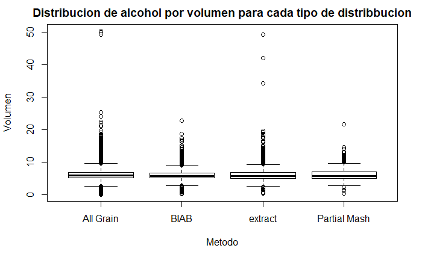

```r
boxplot(ABV~BrewMethod,data=clean_beer, main="Distribucion de alcohol por volumen para cada tipo de distribbucion",
   xlab="Metodo", ylab="Volumen")
```

## 3.2 Means

Guardamos en la variable mean la informacion de ABV y lo visualizamos

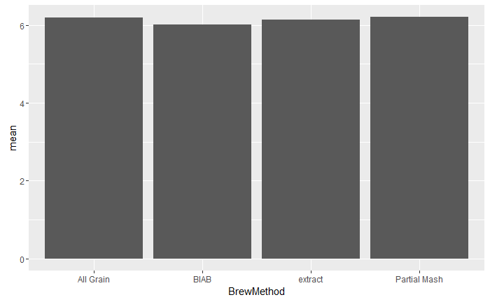

```r
means <- mean_sd_clean_beer %>%
  select(BrewMethod, mean)
ggplot(means, aes(BrewMethod, mean)) +
  geom_bar(stat="identity", position = "dodge") +
  scale_fill_brewer(palette = "Set1")
```

## 3.3 ANOVA

Usamos la funcion aov para realizar una analisis de anova y ver la variabilidad entre los diferentes metodos

```r
myaov <- aov(ABV~BrewMethod, beer)
myaov
```

```
Call:
   aov(formula = ABV ~ BrewMethod, data = beer)

Terms:
                BrewMethod Residuals
Sum of Squares      273.56 261752.94
Deg. of Freedom          3     73857

Residual standard error: 1.882565
Estimated effects may be unbalanced
```

```r
summary(myaov)
```

```
               Df Sum Sq Mean Sq F value Pr(>F)
BrewMethod      3    274   91.19   25.73 <2e-16 ***
Residuals   73857 261753    3.54
---
Signif. codes:  0 ‘***’ 0.001 ‘**’ 0.01 ‘*’ 0.05 ‘.’ 0.1 ‘ ’ 1
```

## 3.4 Comprobar los cálculos

Calculamos manualmente SSB y SSW

```r
brewinggrouped <- beer %>%
  group_by(BrewMethod) %>%
  summarise(x = sum((ABV - mean(ABV)) ^ 2))
SSW <- brewinggrouped %>%
        summarise(ssw = sum(x))
SSW
```

| ssw |
| --- |
| 261752.9 |

```r
SST <- sum (( brewinggrouped$x - mean(brewinggrouped$x)) ^ 2)
SSB <- SST - SSW
SSB
```

| ssw |
| --- |
| 14295871964 |

```r
SST
```

```
[1] 14296133717
```

```r
m <- 4
N <- length(brewinggrouped$BrewMethod)
F <- (SSB/ (m-1)) / (SSW/(N-m))
F
```

| ssw |
| --- |
| 0 |

## 3.5 Tests a posteriori

Realizamos la prueba de tukey-

```r
tukey <- TukeyHSD(myaov)
tukey
```

```
  Tukey multiple comparisons of means
    95% family-wise confidence level

Fit: aov(formula = ABV ~ BrewMethod, data = beer)

$BrewMethod
                              diff          lwr           upr     p adj
BIAB-All Grain         -0.15970174 -0.208867973 -0.1105355004 0.0000000
extract-All Grain      -0.05668014 -0.113092308 -0.0002679765 0.0484020
Partial Mash-All Grain  0.04636046 -0.037916098  0.1306370276 0.4909909
extract-BIAB            0.10302159  0.034770342  0.1712728475 0.0006098
Partial Mash-BIAB       0.20606220  0.113442333  0.2986820705 0.0000001
Partial Mash-extract    0.10304061  0.006379065  0.1997021494 0.0313677
```

Lo representamos graficamente

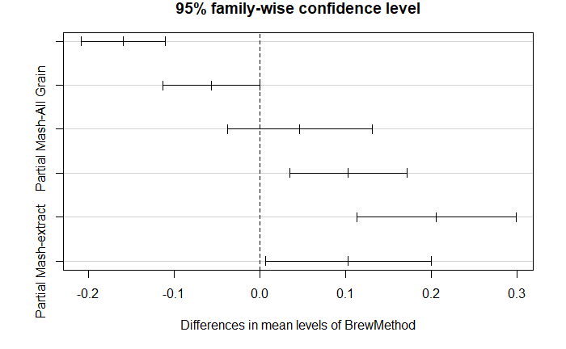

```r
plot(tukey)
```

# 4 Componentes principales

## 4.1 Preparación de datos

```r
beerpc <- clean_beer %>%
  select(Size.L., OG, FG, ABV, IBU, Color, BoilSize, BoilTime, BoilGravity, Efficiency, MashThickness, PitchRate, PrimaryTemp)
```

## 4.2 Matriz de correlación

Mostramos las correlaciones entre las variables

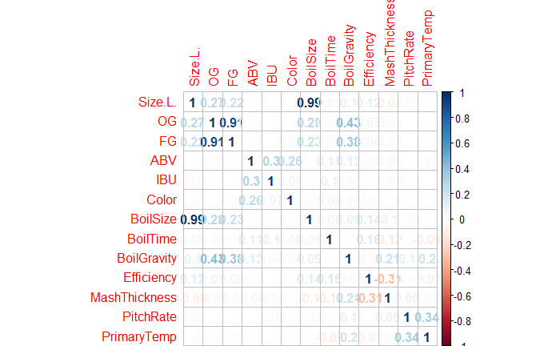

```r
corrplot(cor(beerpc), method = "number")
```

Vemos como hay una correlacion muy alta entre boilsize y size l, al igual que tambien hay una correlacion alta entre fg y og. Entre las demas varaibles no hay una correlacion que destaque, la mayor es de 0.43 entre og y boilgravity.

## 4.3 PCA

Calculamos el modelo PCA

```r
pca <- prcomp(beerpc)
summary(pca)
```

```
Importance of components:
                            PC1      PC2     PC3      PC4      PC5      PC6      PC7      PC8     PC9   PC10    PC11
Standard deviation     215.4693 174.9963 99.1974 57.22449 37.33415 15.50403 12.29049 11.49809 9.18399 3.0176 1.80868
Proportion of Variance   0.5036   0.3322  0.1067  0.03552  0.01512  0.00261  0.00164  0.00143 0.00091 0.0001 0.00004
Cumulative Proportion    0.5036   0.8358  0.9426  0.97812  0.99324  0.99585  0.99749  0.99892 0.99984 0.9999 0.99997
                          PC12   PC13
Standard deviation     1.65126 0.1737
Proportion of Variance 0.00003 0.0000
Cumulative Proportion  1.00000 1.0000
```

## 4.4 Estandarización

Calculamos PCA estandarizado y comparamos resultados.

```r
pca_standard <- prcomp(beerpc, scale. = TRUE)
summary(pca_standard)
```

```
Importance of components:
                          PC1    PC2    PC3    PC4     PC5     PC6     PC7     PC8     PC9    PC10    PC11    PC12    PC13
Standard deviation     1.6278 1.3203 1.2403 1.1830 1.08421 0.96962 0.94934 0.86582 0.82428 0.78875 0.71084 0.30055 0.07450
Proportion of Variance 0.2038 0.1341 0.1183 0.1076 0.09042 0.07232 0.06933 0.05767 0.05226 0.04786 0.03887 0.00695 0.00043
Cumulative Proportion  0.2038 0.3379 0.4562 0.5639 0.65432 0.72664 0.79597 0.85363 0.90590 0.95376 0.99262 0.99957 1.00000
```

Vemos como los resultados dan mucho mas bajos, sobre todo en la desviacion standard, esto ocurre por la variabilidad, al scalarlo y estandarizar los resultados entre dos numeros iguales para todas las variables es mas factible la comparacion.

## 4.5 Visualizar el modelo generado

Usamos un scatter plot del conjunto para mostrar, en este caso al ser muchos los campos no se puede visualizar de manera correcta.

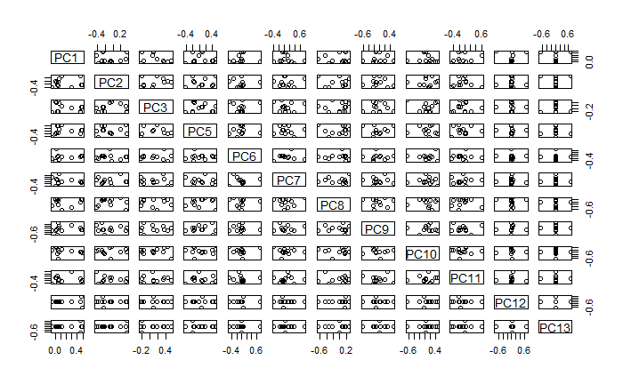